# Cleaning r/biotech Salary Data

Published

October 19, 2026

Modified

October 19, 2026

set out dir

```r
if (interactive()){
  outdir <- here::here()
} else {
  outdir <- here::here(params$outdir)
}
```

# libraries

```r
library(readr)
library(here)
library(purrr)
library(glue)
library(lubridate)
library(forcats)
library(dplyr)
library(tidyr)
library(gt)
library(ggplot2)
library(skimr)
library(janitor)
library(stringr)
library(tictoc)
library(usethis)
library(reactable)
```

# preprocess excel data

[link to google sheets](https://docs.google.com/spreadsheets/d/1G0FmJhkOME_sv66hWmhnZS5qR2KMTY7nzkxksv46bfk/edit#gid=491268892)

I extract the sheets into separate csv files so that they can display on github and be more easily used.

```r
# run this once, manually
library(googlesheets4)
gs4_deauth()
google_sheets_url <- 'https://docs.google.com/spreadsheets/d/1G0FmJhkOME_sv66hWmhnZS5qR2KMTY7nzkxksv46bfk/edit#gid=491268892'
sheet_names <- googlesheets4::sheet_names(google_sheets_url)
```

# yearly survey version differences

```r
sal <- sheet_names |>
  # read it as character values to avoid list-column headaches
  map(
    \(x) read_sheet(google_sheets_url, sheet = x, col_types = 'c')
  )
```

```
✔ Reading from "r/biotech salary and company survey".
```

```
✔ Range ''2026''.
```

```
✔ Reading from "r/biotech salary and company survey".
```

```
✔ Range ''2025''.
```

```
✔ Reading from "r/biotech salary and company survey".
```

```
✔ Range ''2024''.
```

```
✔ Reading from "r/biotech salary and company survey".
```

```
✔ Range ''2023''.
```

```
✔ Reading from "r/biotech salary and company survey".
```

```
✔ Range ''2022''.
```

```r
sal <-  sal |>
  set_names(sheet_names) |>
  bind_rows(.id = 'sheet_name')
sal  |>  glimpse()
```

```
Rows: 4,079
Columns: 69
$ sheet_name                                                                                                                                                                                                                                                                                                …
$ Timestamp                                                                                                                                                                                                                                                                                                 …
$ `Which country do you work in?`                                                                                                                                                                                                                                                                           …
$ `What City do you work in?`                                                                                                                                                                                                                                                                               …
$ `Which US state do you work in?`                                                                                                                                                                                                                                                                          …
$ `Which Canadian Province do you work in?`                                                                                                                                                                                                                                                                 …
$ `Company or Institution Name`                                                                                                                                                                                                                                                                             …
$ `Which of the following best describes your company?`                                                                                                                                                                                                                                                     …
$ `Biotech sub industry?`                                                                                                                                                                                                                                                                                   …
$ `Company Detail - Approximate Company Size`                                                                                                                                                                                                                                                               …
$ `What is your official job title?\n\nThis should match the title that was present on your offer letter. \n\nSome examples: Research Associate, Scientist, Scientist I/II/III, Senior Scientist, Principal Scientist, Manager, Lab Technician, VP, Director etc.\n\nIf your job title includes additional d…
$ `Which department best describes your role? If you can't find one that fits your specific role, select 'Other' and describe`                                                                                                                                                                              …
$ `Briefly describe your position and responsibilities`                                                                                                                                                                                                                                                     …
```

[output cut: 56 more lines]

```r
sal |> count(sheet_name)
```

```
# A tibble: 5 × 2
  sheet_name     n
  <chr>      <int>
1 2022         576
2 2023         670
3 2024        1753
4 2025         903
5 2026         177
```

```r
missing_variables_by_year <- sal |>
  summarize(
    .by = sheet_name,
    across(everything(), ~sum(is.na(.)))
  ) |>
  pivot_longer(
    cols = -c(sheet_name),
    names_to = 'variable',
    values_to = 'n_missing'
  ) |>
  arrange(desc(sheet_name), desc(n_missing))
missing_variables_by_year |>   reactable(groupBy = 'sheet_name')
```

| sheet_name | variable | n_missing |
| --- | --- | --- |
| 2026 | Email Address | 177 |
| 2026 | What degrees do you have? | 177 |
| 2026 | How many total years of experience in post-docs do you have? (If none, enter 0) | 177 |
| 2026 | What currency will you be answering these quesitons in? | 177 |
| 2026 | What country do you work in? | 177 |
| 2026 | Where is the closest major city or hub? | 177 |
| 2026 | Where are you located? | 177 |
| 2026 | Company Details - public/private/start-up/ subsidiary of | 177 |
| 2026 | Role / Title of current position | 177 |
| 2026 | [Optional] Briefly describe your position | 177 |

[output cut: 330 more lines]

# Initial exploratory

## Completeness

Look at response rate per question (number of NAs):

```r
# assess NAs
percent_na <- function(x, invert = FALSE) {
  p <- sum(is.na(x)) / length(x)
  if (invert) { p <- 1 - p}
  p
}

completeness <- sal |>
  summarize(
    .by = sheet_name,
    across(everything(), ~percent_na(.x, invert = TRUE))
  )   |>
  mutate(across(everything(), ~ifelse(. == 0, NA, .))) |>
  pivot_longer(-sheet_name, names_to = 'variable', values_to = '% responded') |>
  pivot_wider(names_from = sheet_name, values_from = '% responded')

reactable_na <- function(df) {
  df |>
    gt() |>
    fmt_percent(columns = -variable, decimals = 0) |>
    data_color(
      columns = -variable,
      palette = c('white', 'blue'),
      na_color = 'white',
      domain = c(0, 1)) |>
    sub_missing(missing_text = '0') |>
    tab_options(table.width = px(500))
}
reactable_na(completeness)
```

| variable | 2026 | 2025 | 2024 | 2023 | 2022 |
| --- | --- | --- | --- | --- | --- |
| Timestamp | 100% | 100% | 100% | 100% | 100% |
| Which country do you work in? | 100% | 100% | 0 | 0 | 0 |
| What City do you work in? | 9% | 11% | 0 | 0 | 0 |
| Which US state do you work in? | 88% | 86% | 0 | 0 | 0 |
| Which Canadian Province do you work in? | 3% | 3% | 0 | 0 | 0 |
| Company or Institution Name | 100% | 100% | 100% | 100% | 26% |
| Which of the following best describes your company? | 100% | 100% | 0 | 0 | 0 |
| Biotech sub industry? | 100% | 100% | 100% | 100% | 100% |
| Company Detail - Approximate Company Size | 99% | 100% | 99% | 100% | 99% |
| What is your official job title? This should match the title that was present on your offer letter. Some examples: Research Associate, Scientist, Scientist I/II/III, Senior Scientist, Principal Scient… | 100% | 100% | 0 | 0 | 0 |
| Which department best describes your role? If you can't find one that fits your specific role, select 'Other' and describe | 100% | 100% | 0 | 0 | 0 |
| Briefly describe your position and responsibilities | 50% | 57% | 0 | 0 | 0 |
| Do you work In-Person, Remote, or Hybrid? | 100% | 100% | 0 | 0 | 0 |
| How many days on average per week do you work from home? | 100% | 100% | 0 | 0 | 0 |
| Work Life Balance - On average, how many hours do you work per week | 100% | 100% | 0 | 0 | 0 |
| Select the highest level of education that you have that's relevant to your occupation. If you have multiple (e.g. PhD + MD) please select "Other" and describe | 100% | 100% | 0 | 0 | 0 |
| If you are a post-doc, how many years have you been a post-doc for? (answer in years) | 42% | 0 | 0 | 0 | 0 |
| List other relevant and recognized certifications | 7% | 8% | 100% | 100% | 0 |
| Please enter your total years of experience in the field DO NOT INCLUDE years in BSc, Masters, PhD, or post-bacc/post-doc | 100% | 100% | 0 | 0 | 0 |
| How many years have you been working at this current position? | 100% | 100% | 0 | 0 | 0 |
| What currency will you be answering these questions in? | 100% | 0 | 0 | 0 | 0 |
| Are you a salaried or hourly employee | 100% | 100% | 0 | 0 | 0 |
| If you are an hourly employee, how many hours per week do you work? | 39% | 100% | 0 | 0 | 0 |
| Annual Base Salary What is your annual BASE salary? Do not include bonus or stocks If you are paid hourly, multiply by 2080 to convert to yearly (assuming you work 40hr/week) | 100% | 100% | 0 | 0 | 0 |
| Overtime Pay How is overtime handled on a per hour basis? (1.5x base, 2x base, etc) | 53% | 100% | 0 | 0 | 0 |
| Annual Target Bonus in PERCENTAGE (%) This should be stipulated prior to your employment. DO NOT include one-time bonuses (spot bonuses, signing bonuses, referral bonuses). | 82% | 85% | 0 | 0 | 0 |
| Any other type of annual bonus? Please describe. DO NOT include one-time bonuses (spot bonuses, signing bonuses, referral bonuses). | 21% | 23% | 0 | 0 | 0 |
| How much of your bonus did you receive in the last cycle? e.g. maybe your target bonus was 10%, but you actually got 8% this year. So here you would write "8%" | 64% | 59% | 0 | 0 | 0 |
| Commission If you are compensated with commission how much is your commission? (Please indicate if answering in percentage or absolute monetary value) | 100% | 100% | 0 | 0 | 0 |
| Annual Equity/Stock Option Please enter the grant/market value of your long-term incentive. Use the annualized amount if distributed over several years. Enter 0 if none or not applicable. DO NOT inclu… | 100% | 100% | 0 | 0 | 0 |
| Most recent annual yearly raise (%) Companies typically do yearly raises across the board for all employees. This is not to be confused with promotions or raises that were requested. | 100% | 100% | 0 | 0 | 0 |
| Retirement Benefits (free text) Briefly describe retirement benefits. For example 401k match %, pension, etc | 64% | 69% | 0 | 0 | 0 |
| Healthcare Benefits (free text) Describe healthcare benefits - costs, deductibles, outfamily plan, insurance provider, total out of pocket, HSA contributions, etc | 37% | 46% | 0 | 0 | 0 |
| [Sign on] Bonus Value This is a one-time bonus you may have received when signing-on. This is not a bonus that reoccurs | 29% | 41% | 0 | 0 | 0 |
| [Sign on] Stock/Equity Options Briefly describe sign on stock/equity options that is available | 26% | 37% | 0 | 0 | 0 |
| [Sign on] Relocation Assistance Total Value This is the total value of the relocation assistance including but not limited to tax-true ups company may have paid, movers expenses, shipping of vehicles,… | 24% | 34% | 0 | 0 | 0 |
| Provide a review and rate your company/institution and experience | 32% | 35% | 0 | 0 | 0 |
| Survey feedback | 8% | 10% | 0 | 0 | 0 |
| Email Address | 0 | 0 | 0 | 0 | 0 |
| What degrees do you have? | 0 | 0 | 100% | 0 | 0 |
| How many total years of experience in post-docs do you have? (If none, enter 0) | 0 | 100% | 0 | 0 | 0 |
| What currency will you be answering these quesitons in? | 0 | 100% | 0 | 0 | 0 |
| What country do you work in? | 0 | 0 | 10% | 100% | 0 |
| Where is the closest major city or hub? | 0 | 0 | 10% | 100% | 100% |
| Where are you located? | 0 | 0 | 90% | 0 | 0 |
| Company Details - public/private/start-up/ subsidiary of | 0 | 0 | 100% | 100% | 100% |
| Role / Title of current position | 0 | 0 | 100% | 100% | 100% |
| [Optional] Briefly describe your position | 0 | 0 | 48% | 52% | 0 |
| Years of Experience | 0 | 0 | 100% | 100% | 100% |
| Compensation - Annual Base Salary/Pay | 0 | 0 | 100% | 100% | 100% |
| Compensation - Overtime Pay | 0 | 0 | 100% | 100% | 0 |
| Compensation - Annual Target Bonus ($) | 0 | 0 | 100% | 100% | 100% |
| Compensation - Annual Equity/Stock Option | 0 | 0 | 100% | 0 | 0 |
| Compensation - Most recent annual yearly raise (%) | 0 | 0 | 100% | 100% | 0 |
| Compensation - Sign on Bonus Value | 0 | 0 | 50% | 51% | 37% |
| Compensation - Sign on Stock/Equity Options | 0 | 0 | 38% | 0 | 0 |
| Compensation - Retirement Benefits (free text) | 0 | 0 | 97% | 64% | 0 |
| Compensation - Retirement Percent Match (free text) | 0 | 0 | 0 | 0 | 0 |
| Compensation - Healthcare Benefits (free text) | 0 | 0 | 44% | 41% | 0 |
| [OPTIONAL] Sign on - Relocation Assistance Total Value | 0 | 0 | 21% | 18% | 24% |
| [Optional] Company Review | 0 | 0 | 23% | 23% | 0 |
| [Optional] Work Life Balance - On average, how many hours do you work per week | 0 | 0 | 94% | 0 | 0 |
| Survey Feedback | 0 | 0 | 6% | 0 | 0 |
| Highest achieved Formal Education | 0 | 0 | 0 | 100% | 100% |
| Compensation - Annual Equity | 0 | 0 | 0 | 100% | 100% |
| Compensation - Stock Options | 0 | 0 | 0 | 41% | 0 |
| Compensation - Options | 0 | 0 | 0 | 0 | 0 |
| Have you one a post-doc? | 0 | 0 | 0 | 0 | 0 |

## Remove those with 0 answers:

```r
# remove variables that are all NA:
var_all_na <- sal |>
  skim()  |>
  filter(n_missing == nrow(sal)) |>
  pull(skim_variable)

message('removing variables that are have all missing values')
```

```
removing variables that are have all missing values
```

```r
sal_clean <- sal |>
  select(-any_of(var_all_na))
message(glue(
  "{length(var_all_na)}/{ncol(sal)} columns removed that are all NA"
))
```

```
4/69 columns removed that are all NA
```

```r
print(var_all_na)
```

```
[1] "Email Address"
[2] "Compensation - Retirement Percent Match (free text)"
[3] "Compensation - Options"
[4] "Have you one a post-doc?"
```

## Rename column names

I rename column names to make them easier to call:

```r
# view changed colnames
tibble(original = colnames(sal)) |>
  mutate(new = janitor::make_clean_names(original)) |>
  gt()
```

| original | new |
| --- | --- |
| sheet_name | sheet_name |
| Timestamp | timestamp |
| Which country do you work in? | which_country_do_you_work_in |
| What City do you work in? | what_city_do_you_work_in |
| Which US state do you work in? | which_us_state_do_you_work_in |
| Which Canadian Province do you work in? | which_canadian_province_do_you_work_in |
| Company or Institution Name | company_or_institution_name |
| Which of the following best describes your company? | which_of_the_following_best_describes_your_company |
| Biotech sub industry? | biotech_sub_industry |
| Company Detail - Approximate Company Size | company_detail_approximate_company_size |
| What is your official job title? This should match the title that was present on your offer letter. Some examples: Research Associate, Scientist, Scientist I/II/III, Senior Scientist, Principal Scient… | what_is_your_official_job_title_this_should_match_the_title_that_was_present_on_your_offer_letter_some_examples_research_associate_scientist_scientist_i_ii_iii_senior_scientist_principal_scientist_man… |
| Which department best describes your role? If you can't find one that fits your specific role, select 'Other' and describe | which_department_best_describes_your_role_if_you_cant_find_one_that_fits_your_specific_role_select_other_and_describe |
| Briefly describe your position and responsibilities | briefly_describe_your_position_and_responsibilities |
| Do you work In-Person, Remote, or Hybrid? | do_you_work_in_person_remote_or_hybrid |
| How many days on average per week do you work from home? | how_many_days_on_average_per_week_do_you_work_from_home |
| Work Life Balance - On average, how many hours do you work per week | work_life_balance_on_average_how_many_hours_do_you_work_per_week |
| Select the highest level of education that you have that's relevant to your occupation. If you have multiple (e.g. PhD + MD) please select "Other" and describe | select_the_highest_level_of_education_that_you_have_thats_relevant_to_your_occupation_if_you_have_multiple_e_g_ph_d_md_please_select_other_and_describe |
| If you are a post-doc, how many years have you been a post-doc for? (answer in years) | if_you_are_a_post_doc_how_many_years_have_you_been_a_post_doc_for_answer_in_years |
| List other relevant and recognized certifications | list_other_relevant_and_recognized_certifications |
| Please enter your total years of experience in the field DO NOT INCLUDE years in BSc, Masters, PhD, or post-bacc/post-doc | please_enter_your_total_years_of_experience_in_the_field_do_not_include_years_in_b_sc_masters_ph_d_or_post_bacc_post_doc |
| How many years have you been working at this current position? | how_many_years_have_you_been_working_at_this_current_position |
| What currency will you be answering these questions in? | what_currency_will_you_be_answering_these_questions_in |
| Are you a salaried or hourly employee | are_you_a_salaried_or_hourly_employee |
| If you are an hourly employee, how many hours per week do you work? | if_you_are_an_hourly_employee_how_many_hours_per_week_do_you_work |
| Annual Base Salary What is your annual BASE salary? Do not include bonus or stocks If you are paid hourly, multiply by 2080 to convert to yearly (assuming you work 40hr/week) | annual_base_salary_what_is_your_annual_base_salary_do_not_include_bonus_or_stocks_if_you_are_paid_hourly_multiply_by_2080_to_convert_to_yearly_assuming_you_work_40hr_week |
| Overtime Pay How is overtime handled on a per hour basis? (1.5x base, 2x base, etc) | overtime_pay_how_is_overtime_handled_on_a_per_hour_basis_1_5x_base_2x_base_etc |
| Annual Target Bonus in PERCENTAGE (%) This should be stipulated prior to your employment. DO NOT include one-time bonuses (spot bonuses, signing bonuses, referral bonuses). | annual_target_bonus_in_percentage_percent_this_should_be_stipulated_prior_to_your_employment_do_not_include_one_time_bonuses_spot_bonuses_signing_bonuses_referral_bonuses |
| Any other type of annual bonus? Please describe. DO NOT include one-time bonuses (spot bonuses, signing bonuses, referral bonuses). | any_other_type_of_annual_bonus_please_describe_do_not_include_one_time_bonuses_spot_bonuses_signing_bonuses_referral_bonuses |
| How much of your bonus did you receive in the last cycle? e.g. maybe your target bonus was 10%, but you actually got 8% this year. So here you would write "8%" | how_much_of_your_bonus_did_you_receive_in_the_last_cycle_e_g_maybe_your_target_bonus_was_10_percent_but_you_actually_got_8_percent_this_year_so_here_you_would_write_8_percent |
| Commission If you are compensated with commission how much is your commission? (Please indicate if answering in percentage or absolute monetary value) | commission_if_you_are_compensated_with_commission_how_much_is_your_commission_please_indicate_if_answering_in_percentage_or_absolute_monetary_value |
| Annual Equity/Stock Option Please enter the grant/market value of your long-term incentive. Use the annualized amount if distributed over several years. Enter 0 if none or not applicable. DO NOT inclu… | annual_equity_stock_option_please_enter_the_grant_market_value_of_your_long_term_incentive_use_the_annualized_amount_if_distributed_over_several_years_enter_0_if_none_or_not_applicable_do_not_include_… |
| Most recent annual yearly raise (%) Companies typically do yearly raises across the board for all employees. This is not to be confused with promotions or raises that were requested. | most_recent_annual_yearly_raise_percent_companies_typically_do_yearly_raises_across_the_board_for_all_employees_this_is_not_to_be_confused_with_promotions_or_raises_that_were_requested |
| Retirement Benefits (free text) Briefly describe retirement benefits. For example 401k match %, pension, etc | retirement_benefits_free_text_briefly_describe_retirement_benefits_for_example_401k_match_percent_pension_etc |
| Healthcare Benefits (free text) Describe healthcare benefits - costs, deductibles, outfamily plan, insurance provider, total out of pocket, HSA contributions, etc | healthcare_benefits_free_text_describe_healthcare_benefits_costs_deductibles_outfamily_plan_insurance_provider_total_out_of_pocket_hsa_contributions_etc |
| [Sign on] Bonus Value This is a one-time bonus you may have received when signing-on. This is not a bonus that reoccurs | sign_on_bonus_value_this_is_a_one_time_bonus_you_may_have_received_when_signing_on_this_is_not_a_bonus_that_reoccurs |
| [Sign on] Stock/Equity Options Briefly describe sign on stock/equity options that is available | sign_on_stock_equity_options_briefly_describe_sign_on_stock_equity_options_that_is_available |
| [Sign on] Relocation Assistance Total Value This is the total value of the relocation assistance including but not limited to tax-true ups company may have paid, movers expenses, shipping of vehicles,… | sign_on_relocation_assistance_total_value_this_is_the_total_value_of_the_relocation_assistance_including_but_not_limited_to_tax_true_ups_company_may_have_paid_movers_expenses_shipping_of_vehicles_temp… |
| Provide a review and rate your company/institution and experience | provide_a_review_and_rate_your_company_institution_and_experience |
| Survey feedback | survey_feedback |
| Email Address | email_address |
| What degrees do you have? | what_degrees_do_you_have |
| How many total years of experience in post-docs do you have? (If none, enter 0) | how_many_total_years_of_experience_in_post_docs_do_you_have_if_none_enter_0 |
| What currency will you be answering these quesitons in? | what_currency_will_you_be_answering_these_quesitons_in |
| What country do you work in? | what_country_do_you_work_in |
| Where is the closest major city or hub? | where_is_the_closest_major_city_or_hub |
| Where are you located? | where_are_you_located |
| Company Details - public/private/start-up/ subsidiary of | company_details_public_private_start_up_subsidiary_of |
| Role / Title of current position | role_title_of_current_position |
| [Optional] Briefly describe your position | optional_briefly_describe_your_position |
| Years of Experience | years_of_experience |
| Compensation - Annual Base Salary/Pay | compensation_annual_base_salary_pay |
| Compensation - Overtime Pay | compensation_overtime_pay |
| Compensation - Annual Target Bonus ($) | compensation_annual_target_bonus |
| Compensation - Annual Equity/Stock Option | compensation_annual_equity_stock_option |
| Compensation - Most recent annual yearly raise (%) | compensation_most_recent_annual_yearly_raise_percent |
| Compensation - Sign on Bonus Value | compensation_sign_on_bonus_value |
| Compensation - Sign on Stock/Equity Options | compensation_sign_on_stock_equity_options |
| Compensation - Retirement Benefits (free text) | compensation_retirement_benefits_free_text |
| Compensation - Retirement Percent Match (free text) | compensation_retirement_percent_match_free_text |
| Compensation - Healthcare Benefits (free text) | compensation_healthcare_benefits_free_text |
| [OPTIONAL] Sign on - Relocation Assistance Total Value | optional_sign_on_relocation_assistance_total_value |
| [Optional] Company Review | optional_company_review |
| [Optional] Work Life Balance - On average, how many hours do you work per week | optional_work_life_balance_on_average_how_many_hours_do_you_work_per_week |
| Survey Feedback | survey_feedback_2 |
| Highest achieved Formal Education | highest_achieved_formal_education |
| Compensation - Annual Equity | compensation_annual_equity |
| Compensation - Stock Options | compensation_stock_options |
| Compensation - Options | compensation_options |
| Have you one a post-doc? | have_you_one_a_post_doc |

```r
sal_clean <- janitor::clean_names(sal_clean)
```

Now I begin cleaning the variable values

# Column cleaning

It would be a massive effort to clean every column. Let’s prioritize to most important ones:

- Salary
- base
- target bonus (%)
- equity
- Title
- Experience
- years
- degree
- Location
- country
- city

If I have time, can look also at:

- 401k match

## salary

- base
- target bonus (%)
- equity

### base

Which column corresponds to base salary?

```r
completeness |> filter(str_detect(tolower(variable), 'salary')) |>  reactable_na()
```

| variable | 2026 | 2025 | 2024 | 2023 | 2022 |
| --- | --- | --- | --- | --- | --- |
| Annual Base Salary What is your annual BASE salary? Do not include bonus or stocks If you are paid hourly, multiply by 2080 to convert to yearly (assuming you work 40hr/week) | 100% | 100% | 0 | 0 | 0 |
| Compensation - Annual Base Salary/Pay | 0 | 0 | 100% | 100% | 100% |

2025 we changed the question, added data validation so that it has to be digits

before 2025, it was a short-form text, so it needed a lot of data cleaning.

2025 looks like this

I rename to `compensation_annual_base_salary_pay_2025` first

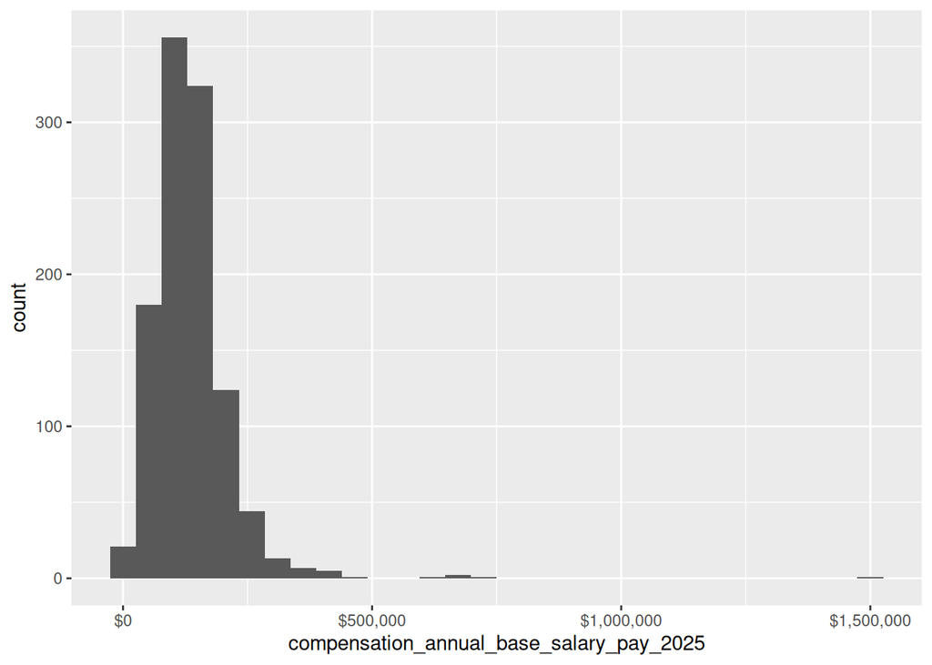

```r
sal_clean <- sal_clean |> rename(
  compensation_annual_base_salary_pay_2025  = annual_base_salary_what_is_your_annual_base_salary_do_not_include_bonus_or_stocks_if_you_are_paid_hourly_multiply_by_2080_to_convert_to_yearly_assuming_you_work_40hr_week
)
sal_clean <- sal_clean |> mutate(compensation_annual_base_salary_pay_2025 = as.numeric(compensation_annual_base_salary_pay_2025))

sal_clean |>
  select(compensation_annual_base_salary_pay_2025 ) |>
  ggplot(aes(x = compensation_annual_base_salary_pay_2025 )) +
  geom_histogram() +
  scale_x_continuous(labels = scales::dollar)
```

Since it looks good I will coaelesce 2025 with previous years:

```r
sal_clean <- sal_clean |>
  mutate(compensation_annual_base_salary_pay = ifelse(
    is.na(compensation_annual_base_salary_pay),
    compensation_annual_base_salary_pay_2025,
    compensation_annual_base_salary_pay
  )) |>
  select(-compensation_annual_base_salary_pay_2025)
```

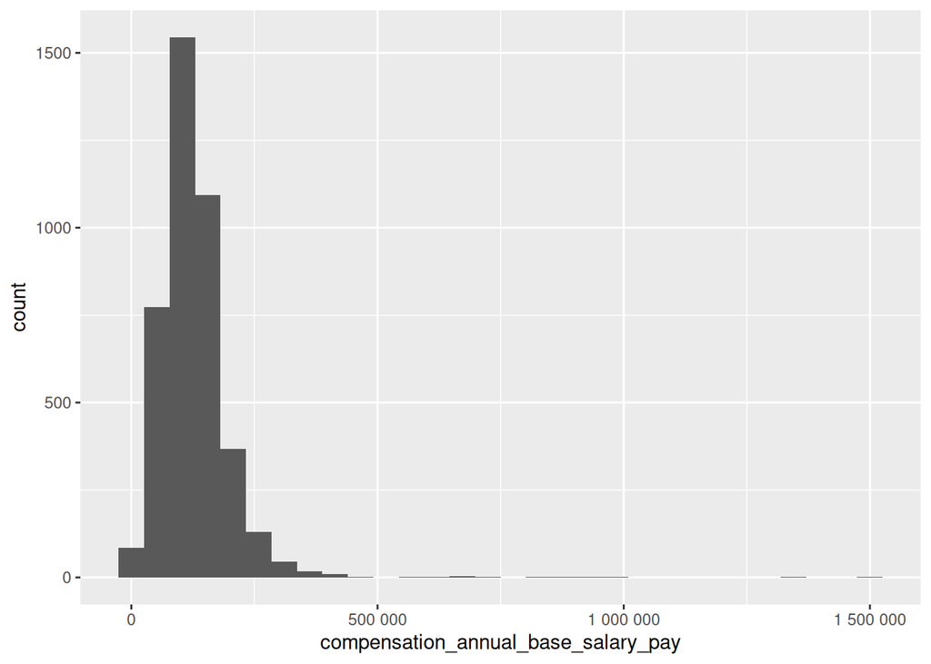

```r
# make numeric
sal_clean <- sal_clean |>
  mutate(
    across(
      c(compensation_annual_base_salary_pay,
        compensation_annual_target_bonus), ~as.numeric(.x))
  )
sal_clean |>
  ggplot(aes(x = compensation_annual_base_salary_pay)) +
  geom_histogram() +
  scale_x_continuous(labels = scales::number)
```

```r
# a bunch of salary entries that are <1000:
sal_clean |>
  filter(compensation_annual_base_salary_pay < 5000) |>
  count(compensation_annual_base_salary_pay)
```

```
# A tibble: 42 × 2
   compensation_annual_base_salary_pay     n
                                 <dbl> <int>
 1                                 0       2
 2                                 1       1
 3                                15       1
 4                                23.6     1
 5                                24       1
 6                                28.4     1
 7                                38       1
 8                                45.8     1
 9                                58       1
10                                62       1
# ℹ 32 more rows
```

```r
# remove guy with "1" in base
sal_clean_filt <- sal_clean |>
  filter(compensation_annual_base_salary_pay > 1)
n_removed <- nrow(sal_clean) - nrow(sal_clean_filt)

# 1 guy added extra 0
sal_clean_filt <- sal_clean_filt |>
  mutate(compensation_annual_base_salary_pay = ifelse(
    compensation_annual_base_salary_pay == 1350000 &
      sheet_name == '2023',
    1350000/10,
    compensation_annual_base_salary_pay
  ))

# for the remainder of individuals with salary < 5000 (all in hundreds),
# multiply by 1000
sal_clean_filt <- sal_clean_filt |>
  mutate(
    salary_base = ifelse(
      compensation_annual_base_salary_pay < 1000,
      compensation_annual_base_salary_pay*1000,
      compensation_annual_base_salary_pay
    ))

n_changed <- sal_clean_filt |>
  filter(salary_base != compensation_annual_base_salary_pay) |>
  nrow()
```

We removed 3 data point, and changed / cleaned 46

```r
sal_clean_filt |>
  filter(salary_base != compensation_annual_base_salary_pay) |>
  select(compensation_annual_base_salary_pay, salary_base) |>
  gt()
```

| compensation_annual_base_salary_pay | salary_base |
| --- | --- |
| 170.00 | 170000 |
| 185.00 | 185000 |
| 375.00 | 375000 |
| 175.00 | 175000 |
| 100.00 | 100000 |
| 45.83 | 45830 |
| 38.00 | 38000 |
| 102.00 | 102000 |
| 120.00 | 120000 |
| 77.00 | 77000 |
| 195.00 | 195000 |
| 200.00 | 200000 |
| 100.00 | 100000 |
| 168.00 | 168000 |
| 276.00 | 276000 |
| 109.00 | 109000 |
| 23.65 | 23650 |
| 58.00 | 58000 |
| 100.00 | 100000 |
| 87.00 | 87000 |
| 115.00 | 115000 |
| 220.00 | 220000 |
| 118.00 | 118000 |
| 15.00 | 15000 |
| 62.00 | 62000 |
| 160.00 | 160000 |
| 110.00 | 110000 |
| 126.00 | 126000 |
| 127.00 | 127000 |
| 105.00 | 105000 |
| 198.00 | 198000 |
| 170.00 | 170000 |
| 210.00 | 210000 |
| 155.00 | 155000 |
| 170.00 | 170000 |
| 100.00 | 100000 |
| 165.00 | 165000 |
| 123.00 | 123000 |
| 125.00 | 125000 |
| 28.37 | 28370 |
| 115.00 | 115000 |
| 70.00 | 70000 |
| 170.00 | 170000 |
| 125.00 | 125000 |
| 24.00 | 24000 |
| 350.00 | 350000 |

### target bonus

Which column corresponds to bonus?

```r
completeness |> filter(str_detect(tolower(variable), 'bonus')) |>  reactable_na()
```

| variable | 2026 | 2025 | 2024 | 2023 | 2022 |
| --- | --- | --- | --- | --- | --- |
| Annual Base Salary What is your annual BASE salary? Do not include bonus or stocks If you are paid hourly, multiply by 2080 to convert to yearly (assuming you work 40hr/week) | 100% | 100% | 0 | 0 | 0 |
| Annual Target Bonus in PERCENTAGE (%) This should be stipulated prior to your employment. DO NOT include one-time bonuses (spot bonuses, signing bonuses, referral bonuses). | 82% | 85% | 0 | 0 | 0 |
| Any other type of annual bonus? Please describe. DO NOT include one-time bonuses (spot bonuses, signing bonuses, referral bonuses). | 21% | 23% | 0 | 0 | 0 |
| How much of your bonus did you receive in the last cycle? e.g. maybe your target bonus was 10%, but you actually got 8% this year. So here you would write "8%" | 64% | 59% | 0 | 0 | 0 |
| Annual Equity/Stock Option Please enter the grant/market value of your long-term incentive. Use the annualized amount if distributed over several years. Enter 0 if none or not applicable. DO NOT inclu… | 100% | 100% | 0 | 0 | 0 |
| [Sign on] Bonus Value This is a one-time bonus you may have received when signing-on. This is not a bonus that reoccurs | 29% | 41% | 0 | 0 | 0 |
| Compensation - Annual Target Bonus ($) | 0 | 0 | 100% | 100% | 100% |
| Compensation - Sign on Bonus Value | 0 | 0 | 50% | 51% | 37% |

```r
sal_clean_filt |>  colnames() |>  str_subset('bonus')
```

```
[1] "annual_target_bonus_in_percentage_percent_this_should_be_stipulated_prior_to_your_employment_do_not_include_one_time_bonuses_spot_bonuses_signing_bonuses_referral_bonuses"
[2] "any_other_type_of_annual_bonus_please_describe_do_not_include_one_time_bonuses_spot_bonuses_signing_bonuses_referral_bonuses"
[3] "how_much_of_your_bonus_did_you_receive_in_the_last_cycle_e_g_maybe_your_target_bonus_was_10_percent_but_you_actually_got_8_percent_this_year_so_here_you_would_write_8_percent"
[4] "annual_equity_stock_option_please_enter_the_grant_market_value_of_your_long_term_incentive_use_the_annualized_amount_if_distributed_over_several_years_enter_0_if_none_or_not_applicable_do_not_include_equity_when_signing_on_or_one_time_equity_bonuses"
[5] "sign_on_bonus_value_this_is_a_one_time_bonus_you_may_have_received_when_signing_on_this_is_not_a_bonus_that_reoccurs"
[6] "compensation_annual_target_bonus"
[7] "compensation_sign_on_bonus_value"
```

2025: `annual_target_bonus_in_percentage_percent_this_should_be_stipulated_prior_to_your_employment_do_not_include_one_time_bonuses_spot_bonuses_signing_bonuses_referral_bonuses`  
2024: `compensation_annual_target_bonus`

```r
sal_clean_filt  |>
  count(annual_target_bonus_in_percentage_percent_this_should_be_stipulated_prior_to_your_employment_do_not_include_one_time_bonuses_spot_bonuses_signing_bonuses_referral_bonuses)  |>
  set_names(nm = c('bonus', 'n')) |>
  gt()
```

| bonus | n |
| --- | --- |
| 0 | 96 |
| 1 | 3 |
| 10 | 172 |
| 100 | 2 |
| 11 | 5 |
| 11.5 | 1 |
| 12 | 59 |
| 12.5 | 16 |
| 13 | 11 |
| 14 | 10 |
| 14.5 | 1 |
| 15 | 156 |
| 16 | 15 |
| 17 | 7 |
| 17.5 | 9 |
| 18 | 17 |
| 18.3 | 1 |
| 19 | 1 |
| 2 | 5 |
| 2.5 | 1 |
| 20 | 85 |
| 21 | 1 |
| 22 | 9 |
| 22.5 | 2 |
| 23 | 7 |
| 24 | 5 |
| 25 | 28 |
| 26 | 1 |
| 27.5 | 1 |
| 28 | 1 |
| 3 | 13 |
| 30 | 14 |
| 32 | 1 |
| 33 | 1 |
| 35 | 3 |
| 4 | 6 |
| 4.5 | 1 |
| 40 | 2 |
| 45 | 1 |
| 5 | 42 |
| 50 | 1 |
| 6 | 14 |
| 6.5 | 4 |
| 7 | 11 |
| 7.5 | 7 |
| 75 | 1 |
| 8 | 48 |
| 8.6 | 1 |
| 9 | 8 |
| 9.5 | 2 |
| NA | 3167 |

2025 looks good, combine it

leave it in the data, but rename to shorter: `bonus_pct_2025`

```r
sal_clean_filt <- sal_clean_filt |>
  rename(bonus_pct_2025 = annual_target_bonus_in_percentage_percent_this_should_be_stipulated_prior_to_your_employment_do_not_include_one_time_bonuses_spot_bonuses_signing_bonuses_referral_bonuses) |>

  mutate(compensation_annual_target_bonus = case_when(
    !is.na(bonus_pct_2025) ~ as.numeric(bonus_pct_2025),
    TRUE ~ compensation_annual_target_bonus
  ))
```

Look at the completeness of bonus now:

```r
sal_clean_filt |>
  count(.by = sheet_name, missing_bonus = is.na(compensation_annual_target_bonus)) |>
  mutate(.by = .by, p = n / sum(n)) |>
  pivot_wider(
    names_from = .by, values_from = c(n, p), names_vary = 'slowest'
  ) |>
  gt() |>
  fmt_percent(contains('p_')) |>
  data_color(
    columns = contains('p_'),
    palette = c('grey', 'forestgreen'),
    na_color = 'white',
    domain = c(0, 1)) |>
  tab_spanner_delim(columns = -missing_bonus, delim = '_', reverse = TRUE)
```

| missing_bonus | 2022 n | 2022 p | 2023 n | 2023 p | 2024 n | 2024 p | 2025 n | 2025 p | 2026 n | 2026 p |
| --- | --- | --- | --- | --- | --- | --- | --- | --- | --- | --- |
| FALSE | 303 | 52.70% | 346 | 51.64% | 913 | 52.11% | 764 | 84.70% | 145 | 81.92% |
| TRUE | 272 | 47.30% | 324 | 48.36% | 839 | 47.89% | 138 | 15.30% | 32 | 18.08% |

**Before 2025:**

is a mix of % and $ amount

I combine this with annual base to create two new variables: bonus_pct, bonus (raw)

My strategy:

1. Remove special characters, except periods which represent decimals
2. convert to numeric, which has two impacts:
- “Not Applicable/None” entries will be converted to NAs
- percentages will be converted from those values that are less than “50”
- raw currency values will be simply those that are above 1000
3. If there is a range of values, then I keep the higher value, since bonus is typically interpreted as the maximum bonus amount, depending on company and individual performance

```r
sal_clean_filt |>
  select(compensation_annual_base_salary_pay,
         compensation_annual_target_bonus) |>
  head(n = 20) |> gt()
```

| compensation_annual_base_salary_pay | compensation_annual_target_bonus |
| --- | --- |
| 165000.00 | NA |
| 161000.00 | 10.0 |
| 128000.00 | 10.0 |
| 120000.00 | 10.0 |
| 135000.00 | 10.0 |
| 85000.00 | 8.0 |
| 150000.00 | 15.0 |
| 85885.79 | 0.0 |
| 150000.00 | 12.0 |
| 83000.00 | 5.0 |
| 235000.00 | 25.0 |
| 298000.00 | 30.0 |
| 155000.00 | NA |
| 132000.00 | 9.0 |
| 120000.00 | 20.0 |
| 180000.00 | 16.0 |
| 81120.00 | 0.0 |
| 275000.00 | 18.3 |
| 72000.00 | 4.0 |
| 127000.00 | 12.0 |

```r
sal_clean_filt <- sal_clean_filt |>
  mutate(
    bonus_cleaned = compensation_annual_target_bonus |>

      # remove special characters
      str_remove_all('[\\$,\\%]') |>

      # remove any non-digits at beginning or end of string
      str_remove('^[^\\d]+') |>
      str_remove('[^\\d]+$') |>

      # if there is text between numbers,
      # split it as likely this represents a range
      str_split('[^\\d\\.]+') |>

      # convert to numeric
      # if it is a range, keep the highest value
      map_dbl(\(x) x |> as.numeric() |> max())
  ) |>

  mutate(bonus_pct = case_when(
    bonus_cleaned < 50 ~ bonus_cleaned/100,
    bonus_cleaned > 1000 ~ bonus_cleaned / salary_base,
    TRUE ~ 0
  ),
  bonus = case_when(
    bonus_cleaned < 50 ~ bonus_pct * salary_base,
    bonus_cleaned > 1000 ~ bonus_cleaned,
    TRUE ~ 0
  ))
```

Let’s look at the cleaned bonus data vs the original:

```r
sal_clean_filt |>

  # take 12 rows, 6 that are different, and then 6 not
  mutate(different = compensation_annual_target_bonus != bonus_cleaned) |>
  slice_sample(n = 6, by = different) |>

  count(salary_base, compensation_annual_target_bonus,
        bonus_cleaned, bonus_pct, bonus)  |>
  arrange(salary_base) |>
  gt() |>
  fmt_percent(bonus_pct) |>
  fmt_currency(c(salary_base, bonus)) |>
  sub_missing()
```

[output not shown]

```r
n_changed_bonus <- sal_clean_filt |>
  filter(salary_base != compensation_annual_base_salary_pay) |>
  nrow()
```

#### filter

These are the responses that put a bonus amount that is nonsensical (> 100%)

I remove these responses completely

```r
# bonus > 100% of base
sal_clean_filt |>
  filter(bonus_pct >= 1)  |>
  select(bonus_pct, bonus_pct_2025, bonus_cleaned, compensation_annual_base_salary_pay)
```

```
# A tibble: 8 × 4
  bonus_pct bonus_pct_2025 bonus_cleaned compensation_annual_base_salary_pay
      <dbl> <chr>                  <dbl>                               <dbl>
1      1    <NA>                  130000                              130000
2      1    <NA>                  125000                              125000
3      1.71 <NA>                  240000                              140000
4      1.15 <NA>                   93000                               81000
5      1.2  <NA>                  169200                              141000
6      1    <NA>                   11100                               11100
7      1    <NA>                   13500                               13500
8      1    <NA>                  140000                              140000
```

```r
sal_clean_filt <- sal_clean_filt |>
  filter(bonus_pct < 1)
```

### total comp

```r
sal_clean_filt <- sal_clean_filt |>
  mutate(salary_total = salary_base + bonus)

sal_clean_filt |>  count(is.na(salary_total))
```

```
# A tibble: 1 × 2
  `is.na(salary_total)`     n
  <lgl>                 <int>
1 FALSE                  4068
```

```r
sal_clean_filt |>  count(is.na(salary_base))
```

```
# A tibble: 1 × 2
  `is.na(salary_base)`     n
  <lgl>                <int>
1 FALSE                 4068
```

```r
sal_clean_filt |>  count(is.na(bonus))
```

```
# A tibble: 1 × 2
  `is.na(bonus)`     n
  <lgl>          <int>
1 FALSE           4068
```

### equity

NOT CURRENTLY ATTEMPTED. Prioritize other data first.

Equity is a little bit complicated:

Some are reported as options, some are reported in 1000s e.g. “15k” vs “15000” Some are reported in $ amount Some say “it varies per year” There are a few that report %, is that amount percentage from base in $ or in options??

1. We set “Not Applicable/None” to 0
2. Set responses that report %, to NA (I don’t want to deal with this and it is a small number of responses)
3. We then create two variables, equity_options, equity_currency_value
- `equity_currency_value` takes those data points that start with a dollar sign $
- `equity_options` is everything else
- treat this the same as base salary:
- clean and then:
- where if it is less than 1000, multiple by 1000
3. Convert everything to numeric

```r
sal_clean_filt |>
  pull(compensation_annual_equity_stock_option) |>
  unique() |>
  head(n = 20)
```

```
 [1] NA
 [2] "8000"
 [3] "Not Applicable/None"
 [4] "10000"
 [5] "500"
 [6] "50000"
 [7] "7800"
 [8] "13000"
 [9] "I don't know beyond sign on"
[10] "Options vested over 4 years. Not sure what the value is since it's paper money."
[11] "20000"
[12] "21000"
[13] "tens to low hundred thousand per year, dep. on stock price"
[14] "2500 Options 1700 rsu"
[15] "250 shares * ~$30/share = ~7500/year"
[16] "12000"
[17] "2200 shares"
[18] "3400"
[19] "30000"
[20] "28800"
```

## Title

What variables correspond to job title?

```r
completeness |> filter(str_detect(tolower(variable), 'title')) |>  reactable_na()
```

| variable | 2026 | 2025 | 2024 | 2023 | 2022 |
| --- | --- | --- | --- | --- | --- |
| What is your official job title? This should match the title that was present on your offer letter. Some examples: Research Associate, Scientist, Scientist I/II/III, Senior Scientist, Principal Scient… | 100% | 100% | 0 | 0 | 0 |
| Role / Title of current position | 0 | 0 | 100% | 100% | 100% |

2025: `What is your official job title? This should match the title that was present on your offer letter. Some examples: Research Associate, Scientist, Scientist I/II/III, Senior Scientist, Principal Scientist, Manager, Lab Technician, VP, Director etc. If your job title includes additional detail, please include e.g. Director of Bioinformatics`

2024: `Role / Title of current position`

rename 2025 variable to `title_2025`

And then merge with 2024 to: `role_title_of_current_position`

```r
sal_clean_filt <- sal_clean_filt |>
  rename(title_2025 = what_is_your_official_job_title_this_should_match_the_title_that_was_present_on_your_offer_letter_some_examples_research_associate_scientist_scientist_i_ii_iii_senior_scientist_principal_scientist_manager_lab_technician_vp_director_etc_if_your_job_title_includes_additional_detail_please_include_e_g_director_of_bioinformatics) |>
  mutate(role_title_of_current_position = case_when(
    is.na(role_title_of_current_position) ~ title_2025,
    TRUE ~ role_title_of_current_position
  ))
```

pre-2025 cleaning:

Title is very important, but also very messy. Titles can have different meanings (compensation, experience, responsibilities) between companies, and location.

```r
sal_clean_filt |>
  count(role_title_of_current_position) |>
  slice_sample(n=10) |>
  gt()
```

| role_title_of_current_position | n |
| --- | --- |
| Client Success Manager | 1 |
| Swnior engineer | 1 |
| BD Manager | 1 |
| Associate Director of Marketing | 1 |
| MSAT | 1 |
| Senior Automation Engineer | 2 |
| RA | 2 |
| QC Chemist I | 1 |
| CAR-T Operations Associate | 1 |
| Downstream Manufacturing Associate I | 1 |

### filtering

Remove some obvious rows

```r
sal_clean_filt <- sal_clean_filt |>
  filter(role_title_of_current_position != 'pimp')
```

### Standardize titles

It’s a lot of work to standardize titles, so I focus on what I know best, scientist-relaeta Let me intialize some empty columns

```r
sal_clean_filt <- sal_clean_filt |>
  mutate(
    title_category = NA_character_,
    title_general = NA_character_,
    title_detail = NA_character_
  )
```

#### Scientist

It’s a lot of work to standardize titles, so I focus on what I know best, scientist

Scientist:

- Research Associate
- Associate Scientist
- Scientist
- Senior Scientist
- Staff Scientist
- Principal Scientist

- `title_category` - Set this to `Scientist`
- `title_general` - A variable that includes general scientist + levels, e.g. Sci **III**, and **Associate** Sci
- `title_detail` - Contains the other detail of job title, e.g. **Research**, **Clinical**

```r
# all roles matching "Scientist"
sal_clean_filt |>
  filter(str_detect(
    role_title_of_current_position, regex('Scientist', ignore_case = FALSE))) |>
  count(role_title_of_current_position) |> head(25) |> gt()
```

| role_title_of_current_position | n |
| --- | --- |
| Advisor (Scientist 1) | 1 |
| Advisor - Quantitative Scientist | 1 |
| Analytical Development Scientist I | 1 |
| Analytical Scientist | 1 |
| Application Development Scientist | 1 |
| Application Scientist | 1 |
| Ass. Scientist | 1 |
| Assistant Scientist | 4 |
| Associate Clinical Trial Scientist | 1 |
| Associate Principal Scientist | 11 |
| Associate Process Scientist | 1 |
| Associate Research Scientist | 4 |
| Associate Scientist | 103 |
| Associate Scientist (R1) | 1 |
| Associate Scientist 1 | 1 |
| Associate Scientist 2 | 3 |
| Associate Scientist 3 | 1 |
| Associate Scientist Doctoral Student | 1 |
| Associate Scientist I | 5 |
| Associate Scientist I/Chemist I | 1 |
| Associate Scientist II | 20 |
| Associate Scientist III | 1 |
| Associate Scientist MSAT | 1 |
| Associate Scientist, Bio-Analytics | 1 |
| Associate Scientist, QC Flow Cytometry | 1 |

Try a different approach:

Hierarchical, see case_when

The order of the statements are impactful e.g.

- If they have associate, they will associate scientists
- If they have associate and “principal” they will be principal scientist

```r
sal_clean_filt <- sal_clean_filt |>
  mutate(
    # title_category
    title_category =
      ifelse(
        str_detect(
          role_title_of_current_position, regex('Scientist', ignore_case = TRUE)),
        'Scientist',
        title_category
      ),

    # scratch
    a = title_category == 'Scientist',
    b = role_title_of_current_position |>
      str_replace_all('sr\\.?', 'Senior'),

    # title detail
    title_detail = ifelse(
      a,
      role_title_of_current_position |>
        str_remove_all(
          regex('(Associate|Scientist|Principal|Senior)*', ignore_case = TRUE)) |>
        str_replace_all('[:punct:]+', ' ') # |>
      # str_replace_all('\\s{2,}', ' ')
      ,
      NA
    )
  ) |>

  # title_gen most specific to most general
  mutate(title_general = case_when(

    a & str_detect(
      b, regex('Principal', ignore_case = TRUE)) ~ 'Principal Scientist',
    a & str_detect(
      b, regex('Senior', ignore_case = TRUE)) ~ 'Senior Scientist',
    a & str_detect(
      b, regex('Associate', ignore_case = TRUE)) ~ 'Associate Scientist',
    a ~ 'Scientist',
  )) |>

  # clean
  select(-a, -b)

sal_clean_filt |>
  count(role_title_of_current_position, title_general, title_detail) |>
  slice_sample(n = 20) |>  gt()
```

| role_title_of_current_position | title_general | title_detail | n |
| --- | --- | --- | --- |
| Associate Director, Operational Excellence | NA | NA | 1 |
| QC Supervisor | NA | NA | 2 |
| Marketing Specialist | NA | NA | 2 |
| Senior Scientist (R3) | Senior Scientist | R3 | 1 |
| Junior Specialist | NA | NA | 1 |
| Principal Machine learning Scientist | Principal Scientist | Machine learning | 1 |
| Sr. Machine learning scientist | Scientist | Sr Machine learning | 1 |
| Production Planning Manager- Clinical Manufacturing | NA | NA | 1 |
| Sr. Product Marketing Manager | NA | NA | 1 |
| CAR-T Operator | NA | NA | 1 |
| Lead Manufacturing Associate | NA | NA | 1 |
| Research Scientist II | Scientist | Research II | 9 |
| Senior Manager | NA | NA | 40 |
| Proposals Supervisor | NA | NA | 1 |
| Contract Scientist | Scientist | Contract | 1 |
| Facility Manager | NA | NA | 1 |
| Senior Consultant | NA | NA | 2 |
| FSE | NA | NA | 1 |
| Sr. Analyst | NA | NA | 1 |
| Bioinformatics Senior Research Associate | NA | NA | 1 |

```r
sal_clean_filt |>  count(title_general) |> gt()
```

| title_general | n |
| --- | --- |
| Associate Scientist | 187 |
| Principal Scientist | 212 |
| Scientist | 932 |
| Senior Scientist | 331 |
| NA | 2405 |

##### filter

remove some outliers upon inspection post deployment

```r
# salary > 800k as scientist
remove <- sal_clean_filt |>
  filter(
    year(mdy_hms(timestamp)) == 2024,
    month(mdy_hms(timestamp)) == 5,
    day(mdy_hms(timestamp)) == 22,
    role_title_of_current_position == 'Scientist'
  ) |>
  pull(timestamp)

# removed
sal_clean_filt |>  filter(timestamp == remove)
```

```
# A tibble: 1 × 72
  sheet_name timestamp          which_country_do_you_wo…¹ what_city_do_you_wor…²
  <chr>      <chr>              <chr>                     <chr>
1 2024       5/22/2024 17:53:21 <NA>                      <NA>
# ℹ abbreviated names: ¹which_country_do_you_work_in, ²what_city_do_you_work_in
# ℹ 68 more variables: which_us_state_do_you_work_in <chr>,
#   which_canadian_province_do_you_work_in <chr>,
#   company_or_institution_name <chr>,
#   which_of_the_following_best_describes_your_company <chr>,
#   biotech_sub_industry <chr>, company_detail_approximate_company_size <chr>,
#   title_2025 <chr>, …
```

```r
sal_clean_filt <- sal_clean_filt |>  filter(timestamp != remove)
```

#### Directors and VP

Same approach as for Scientist, but these are the levels:

```r
sal_clean_filt |>
  filter(str_detect(
    role_title_of_current_position, regex('(Dir(ector)*)|(AD)', ignore_case = TRUE))) |>
  count(role_title_of_current_position) |>  slice_sample(n = 25) |> gt()
```

| role_title_of_current_position | n |
| --- | --- |
| Senior Director, Corporate Communications | 1 |
| Associate Director, Clinical Supplies | 1 |
| Associate Director Validation | 1 |
| Senior Scientist and Team Lead | 1 |
| Director, Regulatory Clinical Science | 1 |
| Director of Business Development | 2 |
| Associate Director of Data Science | 1 |
| Associate Director, Process Development | 1 |
| Sr Scientist 2 (AD equivalent) | 1 |
| Group Leader - Director | 1 |
| Graduate Scientist | 1 |
| Sr Director clinical operations | 1 |
| Director of Research and Development | 1 |
| Project Leader | 3 |
| Director of insight ms and analytics | 1 |
| Senior Advisor (Associate Director level) | 1 |
| Associate Director, Supply Chain | 2 |
| Sr. Director, compliance | 1 |
| Scientific Lead | 1 |
| Director, Translational Science | 1 |
| Executive Director | 7 |
| Sr. Director | 5 |
| Scientific Director | 1 |
| Graduate | 1 |
| Senior Director, Strategy and Operations | 1 |

```r
sal_clean_filt <- sal_clean_filt |>
  mutate(

    # title category
    title_category =
      ifelse(
        str_detect(
          role_title_of_current_position, regex('(Director|\\bAD\\b|\\bDir\\b)', ignore_case = TRUE)),
        'Director',
        title_category
      ),

    # scratch for concise coding
    a = title_category == 'Director',

    # preprocessed
    b = role_title_of_current_position |>
      str_replace_all('sr\\.?', 'Senior') |>
      str_replace_all('\\bAD\\b', 'Associate Director') |>
      str_replace_all('\\bAssoc\\.?\\b', 'Associate') |>
      str_replace_all('\\bDir\\.?\\b', 'Director')
    ,

    # title detail
    title_detail = ifelse(
      a,
      b |>

        # remove the level part + director
        str_remove_all(
          regex('(Associate|Director|Senior|Executive)*', ignore_case = TRUE)) |>
        str_replace_all('[:punct:]+', ' ') # |>
      # str_replace_all('\\s{2,}', ' ')
      ,
      title_detail
    )) |>

  # title_gen most specific to most general
  mutate(title_general = case_when(

    a & str_detect(
      b, regex('Executive', ignore_case = TRUE)) ~ 'Executive Director',
    a & str_detect(
      b, regex('Senior', ignore_case = TRUE)) ~ 'Senior Director',
    a & str_detect(
      b, regex('Associate', ignore_case = TRUE)) ~ 'Associate Director',
    a ~ 'Director',
    .default = title_general
  )) |>

  # clean
  select(-a, -b)
sal_clean_filt |>
  count(
    role_title_of_current_position, title_category,
    title_general, title_detail) |>
  slice_sample(n = 20) |>
  gt()
```

| role_title_of_current_position | title_category | title_general | title_detail | n |
| --- | --- | --- | --- | --- |
| Research Associate 2 | NA | NA | NA | 1 |
| Senior engineer | NA | NA | NA | 1 |
| Senior Associate Engineer | NA | NA | NA | 1 |
| Sr MSL | NA | NA | NA | 1 |
| Senior clinical supply chain manager | NA | NA | NA | 1 |
| Senior Scientist MSAT | Scientist | Senior Scientist | MSAT | 1 |
| Quality Sr Associate | NA | NA | NA | 1 |
| Chemist I | NA | NA | NA | 1 |
| Associates Principal Scientist | Scientist | Principal Scientist | s | 1 |
| Product Sales Specialist | NA | NA | NA | 1 |
| Medical Director, Clinical Development | Director | Director | Medical Clinical Development | 3 |
| Assistant Director | Director | Director | Assistant | 2 |
| Sr. Scientist 1 | Scientist | Scientist | Sr 1 | 2 |
| Case Analyst | NA | NA | NA | 1 |
| EP Mapping Specialist | NA | NA | NA | 1 |
| Postdoctoral Scientist | Scientist | Scientist | Postdoctoral | 2 |
| SRA 1 | NA | NA | NA | 1 |
| Procurement director | Director | Director | Procurement | 1 |
| Director, Medicinal Chemistry | Director | Director | Medicinal Chemistry | 2 |
| Researcher IV | NA | NA | NA | 1 |

```r
sal_clean_filt |>
  filter(title_category == 'Director') |>  count(title_general) |> gt()
```

| title_general | n |
| --- | --- |
| Associate Director | 214 |
| Director | 240 |
| Executive Director | 15 |
| Senior Director | 45 |

- Associate Director
- Director
- Senior Director
- Executive Director

#### VP

There’s not many VPs

```r
sal_clean_filt |>
  filter(str_detect(
    role_title_of_current_position, regex('(VP|Vice Principal)', ignore_case = TRUE))) |>
  count(role_title_of_current_position) |> gt()
```

| role_title_of_current_position | n |
| --- | --- |
| Associate VP, Research Compliance | 1 |
| SVP | 1 |
| SVP, clinical operations | 1 |
| Svp Marketing and BD | 1 |
| VP | 9 |
| VP / CIO | 1 |
| VP Finance | 1 |
| VP Medical Affairs | 1 |
| VP R&D | 1 |
| VP Regulatory | 1 |
| VP Technical Development & Manufacturing | 1 |
| VP clin ops | 1 |
| VP medical affairs | 1 |
| VP of Digital | 1 |
| VP, Marketing | 1 |
| VP, Transformation | 1 |
| VP, Translational Genetics | 1 |
| Vp | 1 |

```r
sal_clean_filt <- sal_clean_filt |>
  mutate(
    title_category =
      ifelse(
        str_detect(
          role_title_of_current_position,
          regex('(VP|Vice Principal)', ignore_case = TRUE)),
        'VP',
        title_category
      ),

    # scratch for concise coding
    a = title_category == 'VP',

    # preprocessed
    b = role_title_of_current_position |>
      str_replace_all(regex('vp', ignore_case = TRUE), 'VP')
    ,

    # title detail
    title_detail = ifelse(
      a,
      b |>

        # remove the level part + title_category
        str_remove_all(
          regex('S?VP', ignore_case = TRUE)) |>
        str_replace_all('[:punct:]+', ' ') |>
        str_replace_all('\\s{2,}', ' ') |>
        str_trim()
      ,
      title_detail
    )) |>

  # title_gen most specific to most general
  mutate(title_general = case_when(

    a & str_detect(
      b, regex('SVP', ignore_case = TRUE)) ~ 'SVP',
    a ~ 'VP',
    .default = title_general
  )) |>

  # clean
  select(-a, -b)

sal_clean_filt |>
  filter(str_detect(
    role_title_of_current_position, regex('vp', ignore_case = TRUE))) |>
  count(
    role_title_of_current_position, title_category,
    title_general, title_detail) |>
  gt()
```

| role_title_of_current_position | title_category | title_general | title_detail | n |
| --- | --- | --- | --- | --- |
| Associate VP, Research Compliance | VP | VP | Associate Research Compliance | 1 |
| SVP | VP | SVP |  | 1 |
| SVP, clinical operations | VP | SVP | clinical operations | 1 |
| Svp Marketing and BD | VP | SVP | Marketing and BD | 1 |
| VP | VP | VP |  | 9 |
| VP / CIO | VP | VP | CIO | 1 |
| VP Finance | VP | VP | Finance | 1 |
| VP Medical Affairs | VP | VP | Medical Affairs | 1 |
| VP R&D | VP | VP | R D | 1 |
| VP Regulatory | VP | VP | Regulatory | 1 |
| VP Technical Development & Manufacturing | VP | VP | Technical Development Manufacturing | 1 |
| VP clin ops | VP | VP | clin ops | 1 |
| VP medical affairs | VP | VP | medical affairs | 1 |
| VP of Digital | VP | VP | of Digital | 1 |
| VP, Marketing | VP | VP | Marketing | 1 |
| VP, Transformation | VP | VP | Transformation | 1 |
| VP, Translational Genetics | VP | VP | Translational Genetics | 1 |
| Vp | VP | VP |  | 1 |

```r
sal_clean_filt |>
  filter(title_category == 'VP') |>  count(title_general) |> gt()
```

| title_general | n |
| --- | --- |
| SVP | 3 |
| VP | 23 |

#### Research Associate

```r
sal_clean_filt |>
  filter(str_detect(
    role_title_of_current_position,
    regex('(Research Associate|\\bRA\\b)', ignore_case = TRUE)
  )) |>
  count(role_title_of_current_position) |> gt()
```

| role_title_of_current_position | n |
| --- | --- |
| Advanced Research Associate | 1 |
| Bioanalytical Principal Research Associate | 1 |
| Bioinformatics Research Associate | 1 |
| Bioinformatics Senior Research Associate | 1 |
| Clinical Research Associate | 2 |
| Contract Research Associate | 1 |
| Manufacturing Research Associate I I | 1 |
| Post-Doctoral Research Associate | 1 |
| Principal Research Associate | 11 |
| Principal Research Associate II | 1 |
| Principal research associate | 2 |
| RA | 2 |
| RA 1 | 1 |
| RA II | 2 |
| Research Associate | 84 |
| Research Associate 2 | 1 |
| Research Associate (Engineer) | 1 |
| Research Associate 1 | 5 |
| Research Associate 111 | 1 |
| Research Associate 2 | 8 |
| Research Associate I | 32 |
| Research Associate I - Protein Purification | 1 |
| Research Associate I, In Vivo | 1 |
| Research Associate II | 59 |
| Research Associate II, Contract | 1 |
| Research Associate III | 11 |
| Research Associate Ii | 1 |
| Research Associate Scientist | 1 |
| Research Associate lvl II | 1 |
| Research Associate, Process Development (Tech Dev Rotational Program) | 1 |
| Research associate | 14 |
| Research associate 2 | 1 |
| Research associate I | 3 |
| Research associate II | 5 |
| Research associate Ii | 1 |
| SENIOR RESEARCH ASSOCIATE | 1 |
| Senior Clinical Research Associate I | 1 |
| Senior RA | 1 |
| Senior Research Associate | 65 |
| Senior Research Associate 1 | 3 |
| Senior Research Associate 2 | 1 |
| Senior Research Associate I | 3 |
| Senior Research Associate II | 3 |
| Senior Research Associate, Analytical Development | 1 |
| Senior Research Associate, Platform Development | 1 |
| Senior Research Associate, Strain Engineering | 1 |
| Senior Research Associates | 1 |
| Senior research associate | 10 |
| Senior research associate I | 2 |
| Sr Research Associate | 5 |
| Sr research associate | 1 |
| Sr. RA | 2 |
| Sr. Research Associate | 16 |
| Sr. Research Associate II | 1 |
| research associate | 2 |
| research associate I | 1 |
| senior research associate | 1 |

```r
sal_clean_filt <- sal_clean_filt |>
  mutate(
    # title_category
    title_category =
      ifelse(
        str_detect(
          role_title_of_current_position,
          regex('(Research Associate|\\bRA\\b)', ignore_case = TRUE)),
        'Research Associate',
        title_category
      ),

    # scratch
    a = title_category == 'Research Associate',
    b = role_title_of_current_position |>
      str_replace_all('[Ss]r\\.?', 'Senior'),

    # title detail
    title_detail = ifelse(
      a,
      role_title_of_current_position |>
        str_remove_all(
          regex('(Research|Associate|Scientist|Senior|\\bRA\\b)*',
                ignore_case = TRUE)) |>
        str_replace_all('[:punct:]+', ' ')  |>
        str_replace_all('\\s{2,}', ' ')
      ,
      title_detail
    )
  ) |>

  # title_gen most specific to most general
  mutate(title_general = case_when(
    a & str_detect(
      b, regex('Senior', ignore_case = TRUE)) ~ 'Senior Research Associate',
    a ~ 'Research Associate',
    .default = title_general
  )) |>

  # clean
  select(-a, -b)

sal_clean_filt |>
  filter(str_detect(
    role_title_of_current_position, regex('(Research Associate|\\bRA\\b)', ignore_case = TRUE))) |>
  count(
    role_title_of_current_position, title_category,
    title_general, title_detail) |>
  gt()
```

| role_title_of_current_position | title_category | title_general | title_detail | n |
| --- | --- | --- | --- | --- |
| Advanced Research Associate | Research Associate | Research Associate | Advanced | 1 |
| Bioanalytical Principal Research Associate | Research Associate | Research Associate | Bioanalytical Principal | 1 |
| Bioinformatics Research Associate | Research Associate | Research Associate | Bioinformatics | 1 |
| Bioinformatics Senior Research Associate | Research Associate | Senior Research Associate | Bioinformatics | 1 |
| Clinical Research Associate | Research Associate | Research Associate | Clinical | 2 |
| Contract Research Associate | Research Associate | Research Associate | Contract | 1 |
| Manufacturing Research Associate I I | Research Associate | Research Associate | Manufacturing I I | 1 |
| Post-Doctoral Research Associate | Research Associate | Research Associate | Post Doctoral | 1 |
| Principal Research Associate | Research Associate | Research Associate | Principal | 11 |
| Principal Research Associate II | Research Associate | Research Associate | Principal II | 1 |
| Principal research associate | Research Associate | Research Associate | Principal | 2 |
| RA | Research Associate | Research Associate |  | 2 |
| RA 1 | Research Associate | Research Associate | 1 | 1 |
| RA II | Research Associate | Research Associate | II | 2 |
| Research Associate | Research Associate | Research Associate |  | 84 |
| Research Associate 2 | Research Associate | Research Associate | 2 | 1 |
| Research Associate (Engineer) | Research Associate | Research Associate | Engineer | 1 |
| Research Associate 1 | Research Associate | Research Associate | 1 | 5 |
| Research Associate 111 | Research Associate | Research Associate | 111 | 1 |
| Research Associate 2 | Research Associate | Research Associate | 2 | 8 |
| Research Associate I | Research Associate | Research Associate | I | 32 |
| Research Associate I - Protein Purification | Research Associate | Research Associate | I Protein Purification | 1 |
| Research Associate I, In Vivo | Research Associate | Research Associate | I In Vivo | 1 |
| Research Associate II | Research Associate | Research Associate | II | 59 |
| Research Associate II, Contract | Research Associate | Research Associate | II Contract | 1 |
| Research Associate III | Research Associate | Research Associate | III | 11 |
| Research Associate Ii | Research Associate | Research Associate | Ii | 1 |
| Research Associate Scientist | Research Associate | Research Associate |  | 1 |
| Research Associate lvl II | Research Associate | Research Associate | lvl II | 1 |
| Research Associate, Process Development (Tech Dev Rotational Program) | Research Associate | Research Associate | Process Development Tech Dev Rotational Program | 1 |
| Research associate | Research Associate | Research Associate |  | 14 |
| Research associate 2 | Research Associate | Research Associate | 2 | 1 |
| Research associate I | Research Associate | Research Associate | I | 3 |
| Research associate II | Research Associate | Research Associate | II | 5 |
| Research associate Ii | Research Associate | Research Associate | Ii | 1 |
| SENIOR RESEARCH ASSOCIATE | Research Associate | Senior Research Associate |  | 1 |
| Senior Clinical Research Associate I | Research Associate | Senior Research Associate | Clinical I | 1 |
| Senior RA | Research Associate | Senior Research Associate |  | 1 |
| Senior Research Associate | Research Associate | Senior Research Associate |  | 65 |
| Senior Research Associate 1 | Research Associate | Senior Research Associate | 1 | 3 |
| Senior Research Associate 2 | Research Associate | Senior Research Associate | 2 | 1 |
| Senior Research Associate I | Research Associate | Senior Research Associate | I | 3 |
| Senior Research Associate II | Research Associate | Senior Research Associate | II | 3 |
| Senior Research Associate, Analytical Development | Research Associate | Senior Research Associate | Analytical Development | 1 |
| Senior Research Associate, Platform Development | Research Associate | Senior Research Associate | Platform Development | 1 |
| Senior Research Associate, Strain Engineering | Research Associate | Senior Research Associate | Strain Engineering | 1 |
| Senior Research Associates | Research Associate | Senior Research Associate | s | 1 |
| Senior research associate | Research Associate | Senior Research Associate |  | 10 |
| Senior research associate I | Research Associate | Senior Research Associate | I | 2 |
| Sr Research Associate | Research Associate | Senior Research Associate | Sr | 5 |
| Sr research associate | Research Associate | Senior Research Associate | Sr | 1 |
| Sr. RA | Research Associate | Senior Research Associate | Sr | 2 |
| Sr. Research Associate | Research Associate | Senior Research Associate | Sr | 16 |
| Sr. Research Associate II | Research Associate | Senior Research Associate | Sr II | 1 |
| research associate | Research Associate | Research Associate |  | 2 |
| research associate I | Research Associate | Research Associate | I | 1 |
| senior research associate | Research Associate | Senior Research Associate |  | 1 |

```r
sal_clean_filt |>
  filter(title_category == 'Research Associate') |>  count(title_general) |> gt()
```

| title_general | n |
| --- | --- |
| Research Associate | 263 |
| Senior Research Associate | 121 |

##### filter

I filter out an outlier sample, looks like they incorrectly inputted bonus:

```r
n_1 <- nrow(sal_clean_filt)
sal_clean_filt |>
  dplyr::filter((
    str_detect(timestamp, '10/31/2023') &
      role_title_of_current_position == 'Sr Clinical Research Associate')
  ) |>
  gt::gt()
sal_clean_filt <- sal_clean_filt |>
  dplyr::filter(!(
    str_detect(timestamp, '10/31/2023') &
      role_title_of_current_position == 'Sr Clinical Research Associate')
  )
.diff <- nrow(sal_clean_filt) - n_1
stopifnot(.diff == -1)
```

[output not shown]

### Roles that have not been processed

Look at the remaining roles that I have not tried to process.

```r
sal_clean_filt |>
  filter(is.na(title_category)) |>
  distinct(role_title_of_current_position) |>
  reactable()
```

| role_title_of_current_position |
| --- |
| Quality assurance manager |
| Lead ops tech |
| Engineer II |
| Engineering Manager |
| Graduate intern |
| Informatics Analyst |
| Sr Mgr Market Access |
| Research Analyst |
| Chief of Clinical Operations |
| Business Development Intern |

[output cut: 1028 more lines]

## Experience

What variables correspond to years of experience?

```r
completeness |> filter(str_detect(tolower(variable), 'experience')) |>  reactable_na()
```

| variable | 2026 | 2025 | 2024 | 2023 | 2022 |
| --- | --- | --- | --- | --- | --- |
| Please enter your total years of experience in the field DO NOT INCLUDE years in BSc, Masters, PhD, or post-bacc/post-doc | 100% | 100% | 0 | 0 | 0 |
| Provide a review and rate your company/institution and experience | 32% | 35% | 0 | 0 | 0 |
| How many total years of experience in post-docs do you have? (If none, enter 0) | 0 | 100% | 0 | 0 | 0 |
| Years of Experience | 0 | 0 | 100% | 100% | 100% |

2025: `Please enter your total years of experience in the field DO NOT INCLUDE years in BSc, Masters, PhD, or post-bacc/post-doc`

2024: `Years of Experience`

rename 2025 variable to `yoe_2025`

And then merge with 2024 to: `years_of_experience`

```r
sal_clean_filt <- sal_clean_filt |>
  rename(yoe_2025 = please_enter_your_total_years_of_experience_in_the_field_do_not_include_years_in_b_sc_masters_ph_d_or_post_bacc_post_doc) |>
  mutate(years_of_experience = case_when(
    is.na(years_of_experience) ~ yoe_2025,
    TRUE ~ years_of_experience
  ))
```

**pre-2025 cleaning:**

```r
sal_clean_filt |>
  count(years_of_experience) |> gt()
```

| years_of_experience | n |
| --- | --- |
| 0 | 283 |
| 1 | 358 |
| 10 | 230 |
| 11 | 87 |
| 12 | 116 |
| 13 | 46 |
| 14 | 46 |
| 15 | 122 |
| 16 | 27 |
| 17 | 29 |
| 18 | 40 |
| 19 | 15 |
| 2 | 407 |
| 20 | 46 |
| 21 | 8 |
| 22 | 8 |
| 23 | 9 |
| 24 | 9 |
| 25 | 23 |
| 26 | 1 |
| 27 | 3 |
| 28 | 1 |
| 3 | 443 |
| 30 | 3 |
| 30 or more | 1 |
| 32 | 2 |
| 4 | 395 |
| 45 | 2 |
| 5 | 367 |
| 6 | 285 |
| 7 | 277 |
| 8 | 236 |
| 9 | 141 |

only 1 will be converted to NA

```r
n_before <- sum(is.na(sal_clean_filt$years_of_experience))
sal_clean_filt <- sal_clean_filt |>
  mutate(years_of_experience = as.numeric(years_of_experience))
n_after <- sum(is.na(sal_clean_filt$years_of_experience))
message(glue('# NAs\nbefore: {n_before}\nafter: {n_after}'))
```

```
# NAs
before: 0
after: 1
```

#### degree

What variables correspond to education?

```r
completeness |> filter(str_detect(tolower(variable), '(degree|edu)')) |>  reactable_na()
```

| variable | 2026 | 2025 | 2024 | 2023 | 2022 |
| --- | --- | --- | --- | --- | --- |
| Select the highest level of education that you have that's relevant to your occupation. If you have multiple (e.g. PhD + MD) please select "Other" and describe | 100% | 100% | 0 | 0 | 0 |
| Healthcare Benefits (free text) Describe healthcare benefits - costs, deductibles, outfamily plan, insurance provider, total out of pocket, HSA contributions, etc | 37% | 46% | 0 | 0 | 0 |
| What degrees do you have? | 0 | 0 | 100% | 0 | 0 |
| Highest achieved Formal Education | 0 | 0 | 0 | 100% | 100% |

2025: `Select the highest level of education that you have that's relevant to your occupation. If you have multiple (e.g. PhD + MD) please select "Other" and describe`

2023: `Highest achieved Formal Education`

rename 2025 variable to `highest_degree_2025`

And then merge with 2024 to: `what_degrees_do_you_have`

```r
sal_clean_filt |>  colnames() |>  str_subset('education')
```

```
[1] "select_the_highest_level_of_education_that_you_have_thats_relevant_to_your_occupation_if_you_have_multiple_e_g_ph_d_md_please_select_other_and_describe"
[2] "highest_achieved_formal_education"
```

```r
sal_clean_filt <- sal_clean_filt |>
  rename(highest_degree_2025 = select_the_highest_level_of_education_that_you_have_thats_relevant_to_your_occupation_if_you_have_multiple_e_g_ph_d_md_please_select_other_and_describe) |>
  mutate(what_degrees_do_you_have = case_when(
    #2025
    is.na(what_degrees_do_you_have) &
      is.na(highest_achieved_formal_education) ~ highest_degree_2025,

    # 2023 2022
    is.na(what_degrees_do_you_have) &
      is.na(highest_degree_2025) ~ highest_achieved_formal_education,

    #2024
    TRUE ~ what_degrees_do_you_have
  ))
```

**pre-2025 cleaning:**

```r
sal_clean_filt |>
  count(what_degrees_do_you_have) |>  gt()
```

| what_degrees_do_you_have | n |
| --- | --- |
| Associates Degree | 4 |
| Associate’s Degree or Equivalent | 30 |
| Associate’s Degree or Equivalent, Bachelors or Equivalent | 4 |
| Bachelor's in pharmacy | 1 |
| Bachelors | 355 |
| Bachelors + post-grad cert | 1 |
| Bachelors degree, almost finished with MS bioE | 1 |
| Bachelors or Equivalent | 1026 |
| Bachelors or Equivalent, Masters or Equivalent | 46 |
| Bachelors or Equivalent, Masters or Equivalent, MD or Equivalent | 2 |
| Bachelors or Equivalent, Masters or Equivalent, PhD or Equivalent | 16 |
| Bachelors or Equivalent, PhD or Equivalent | 10 |
| Bachelors or Equivalent, PharmD or Equivalent | 1 |
| DNP | 1 |
| DVM + MS | 2 |
| High School | 11 |
| High School or Equivalent | 20 |
| High School or Equivalent, Associate’s Degree or Equivalent | 2 |
| High School or Equivalent, Associate’s Degree or Equivalent, Bachelors or Equivalent | 20 |
| High School or Equivalent, Associate’s Degree or Equivalent, Bachelors or Equivalent, Masters or Equivalent | 12 |
| High School or Equivalent, Associate’s Degree or Equivalent, Bachelors or Equivalent, Masters or Equivalent, PhD or Equivalent | 2 |
| High School or Equivalent, Associate’s Degree or Equivalent, Bachelors or Equivalent, PhD or Equivalent | 2 |
| High School or Equivalent, Bachelors or Equivalent | 37 |
| High School or Equivalent, Bachelors or Equivalent, Masters or Equivalent | 40 |
| High School or Equivalent, Bachelors or Equivalent, Masters or Equivalent, JD or Equivalent | 2 |
| High School or Equivalent, Bachelors or Equivalent, Masters or Equivalent, PhD or Equivalent | 13 |
| High School or Equivalent, Bachelors or Equivalent, PhD or Equivalent | 17 |
| High School or Equivalent, Bachelors or Equivalent, PhD or Equivalent, JD or Equivalent | 1 |
| High School or Equivalent, Bachelors or Equivalent, PhD or Equivalent, MD or Equivalent | 3 |
| High School or Equivalent, Bachelors or Equivalent, PharmD or Equivalent | 1 |
| High School or Equivalent, Masters or Equivalent | 1 |
| High School or Equivalent, Masters or Equivalent, PhD or Equivalent | 1 |
| High School or Equivalent, Masters or Equivalent, PharmD or Equivalent | 1 |
| High School or Equivalent, PhD or Equivalent | 1 |
| High School or Equivalent, PharmD or Equivalent | 1 |
| JD | 3 |
| JD + MBA | 1 |
| JD or Equivalent | 1 |
| M.D./PharmD/D.D.S. or Equivalent | 27 |
| MBA | 1 |
| MD | 5 |
| MD + MS | 1 |
| MD or Equivalent | 10 |
| MD, PhD | 1 |
| MS MPH PhD | 1 |
| Masters | 264 |
| Masters or Equivalent | 572 |
| Masters or Equivalent, PhD or Equivalent | 8 |
| Masters or Equivalent, PharmD or Equivalent | 3 |
| PhD | 405 |
| PhD + postdoc + PMP | 1 |
| PhD or Equivalent | 1025 |
| PhD or Equivalent, MD or Equivalent | 3 |
| PhD or Equivalent, PharmD or Equivalent | 2 |
| PharmD | 17 |
| PharmD + Masters in Clinical Research + MBA | 1 |
| PharmD PhD | 1 |
| PharmD or Equivalent | 24 |
| TAFE Diploma | 1 |

contains all degrees, but let’s simplify to the highest degree:

e.g.

- “High School or Equivalent, Bachelors or Equivalent, Masters or Equivalent, PhD or Equivalent”
- “Bachelors or Equivalent, Masters or Equivalent, PhD or Equivalent”
- “Bachelors or Equivalent, PhD or Equivalent”
- “PhD or Equivalent”

should all just be “PhD”

Below code assumes highest degree is the last listed degree

```r
sal_clean_filt <- sal_clean_filt |>
  mutate(experience_highest_degree =  str_extract(
    what_degrees_do_you_have,
    '(?<=,|^)[^,]+$'
  ) |>
    str_replace('M\\.D\\.', 'MD') |>
    str_remove('or Equivalent') |>
    str_replace('MD/Pharm.*', 'MD')
  )

# View Changes
sal_clean_filt |>
  count(is.na(experience_highest_degree), is.na(what_degrees_do_you_have))
```

```
# A tibble: 1 × 3
  `is.na(experience_highest_degree)` `is.na(what_degrees_do_you_have)`     n
  <lgl>                              <lgl>                             <int>
1 FALSE                              FALSE                              4066
```

```r
sal_clean_filt |>
  count(experience_highest_degree, what_degrees_do_you_have) |>
  gt()
```

| experience_highest_degree | what_degrees_do_you_have | n |
| --- | --- | --- |
| Associate’s Degree | High School or Equivalent, Associate’s Degree or Equivalent | 2 |
| Bachelors | Associate’s Degree or Equivalent, Bachelors or Equivalent | 4 |
| Bachelors | High School or Equivalent, Associate’s Degree or Equivalent, Bachelors or Equivalent | 20 |
| Bachelors | High School or Equivalent, Bachelors or Equivalent | 37 |
| JD | High School or Equivalent, Bachelors or Equivalent, Masters or Equivalent, JD or Equivalent | 2 |
| JD | High School or Equivalent, Bachelors or Equivalent, PhD or Equivalent, JD or Equivalent | 1 |
| MD | Bachelors or Equivalent, Masters or Equivalent, MD or Equivalent | 2 |
| MD | High School or Equivalent, Bachelors or Equivalent, PhD or Equivalent, MD or Equivalent | 3 |
| MD | PhD or Equivalent, MD or Equivalent | 3 |
| Masters | Bachelors or Equivalent, Masters or Equivalent | 46 |
| Masters | High School or Equivalent, Associate’s Degree or Equivalent, Bachelors or Equivalent, Masters or Equivalent | 12 |
| Masters | High School or Equivalent, Bachelors or Equivalent, Masters or Equivalent | 40 |
| Masters | High School or Equivalent, Masters or Equivalent | 1 |
| PhD | MD, PhD | 1 |
| PhD | Bachelors or Equivalent, Masters or Equivalent, PhD or Equivalent | 16 |
| PhD | Bachelors or Equivalent, PhD or Equivalent | 10 |
| PhD | High School or Equivalent, Associate’s Degree or Equivalent, Bachelors or Equivalent, Masters or Equivalent, PhD or Equivalent | 2 |
| PhD | High School or Equivalent, Associate’s Degree or Equivalent, Bachelors or Equivalent, PhD or Equivalent | 2 |
| PhD | High School or Equivalent, Bachelors or Equivalent, Masters or Equivalent, PhD or Equivalent | 13 |
| PhD | High School or Equivalent, Bachelors or Equivalent, PhD or Equivalent | 17 |
| PhD | High School or Equivalent, Masters or Equivalent, PhD or Equivalent | 1 |
| PhD | High School or Equivalent, PhD or Equivalent | 1 |
| PhD | Masters or Equivalent, PhD or Equivalent | 8 |
| PharmD | Bachelors or Equivalent, PharmD or Equivalent | 1 |
| PharmD | High School or Equivalent, Bachelors or Equivalent, PharmD or Equivalent | 1 |
| PharmD | High School or Equivalent, Masters or Equivalent, PharmD or Equivalent | 1 |
| PharmD | High School or Equivalent, PharmD or Equivalent | 1 |
| PharmD | Masters or Equivalent, PharmD or Equivalent | 3 |
| PharmD | PhD or Equivalent, PharmD or Equivalent | 2 |
| almost finished with MS bioE | Bachelors degree, almost finished with MS bioE | 1 |
| Associates Degree | Associates Degree | 4 |
| Associate’s Degree | Associate’s Degree or Equivalent | 30 |
| Bachelor's in pharmacy | Bachelor's in pharmacy | 1 |
| Bachelors | Bachelors | 355 |
| Bachelors | Bachelors or Equivalent | 1026 |
| Bachelors + post-grad cert | Bachelors + post-grad cert | 1 |
| DNP | DNP | 1 |
| DVM + MS | DVM + MS | 2 |
| High School | High School | 11 |
| High School | High School or Equivalent | 20 |
| JD | JD | 3 |
| JD | JD or Equivalent | 1 |
| JD + MBA | JD + MBA | 1 |
| MBA | MBA | 1 |
| MD | M.D./PharmD/D.D.S. or Equivalent | 27 |
| MD | MD | 5 |
| MD | MD or Equivalent | 10 |
| MD + MS | MD + MS | 1 |
| MS MPH PhD | MS MPH PhD | 1 |
| Masters | Masters | 264 |
| Masters | Masters or Equivalent | 572 |
| PhD | PhD | 405 |
| PhD | PhD or Equivalent | 1025 |
| PhD + postdoc + PMP | PhD + postdoc + PMP | 1 |
| PharmD | PharmD | 17 |
| PharmD | PharmD or Equivalent | 24 |
| PharmD + Masters in Clinical Research + MBA | PharmD + Masters in Clinical Research + MBA | 1 |
| PharmD PhD | PharmD PhD | 1 |
| TAFE Diploma | TAFE Diploma | 1 |

## Location

What variables correspond to location?

```r
completeness |> filter(str_detect(tolower(variable), '(located|city|country|state|province)')) |>  reactable_na()
```

| variable | 2026 | 2025 | 2024 | 2023 | 2022 |
| --- | --- | --- | --- | --- | --- |
| Which country do you work in? | 100% | 100% | 0 | 0 | 0 |
| What City do you work in? | 9% | 11% | 0 | 0 | 0 |
| Which US state do you work in? | 88% | 86% | 0 | 0 | 0 |
| Which Canadian Province do you work in? | 3% | 3% | 0 | 0 | 0 |
| What country do you work in? | 0 | 0 | 10% | 100% | 0 |
| Where is the closest major city or hub? | 0 | 0 | 10% | 100% | 100% |
| Where are you located? | 0 | 0 | 90% | 0 | 0 |

```r
sal_clean_filt |>  colnames() |>  str_subset('(country|city|state|provin)')
```

```
[1] "which_country_do_you_work_in"
[2] "what_city_do_you_work_in"
[3] "which_us_state_do_you_work_in"
[4] "which_canadian_province_do_you_work_in"
[5] "what_country_do_you_work_in"
[6] "where_is_the_closest_major_city_or_hub"
```

2025: `Which country do you work in?`, `What City do you work in?`, `Which US state do you work in?`, `Which Canadian Province do you work in?`

2024: `Where are you located?`

<2023: `What country do you work in?`, `Where is the closest major city or hub?`

**pre-2025 cleaning:**

```r
sal_clean_filt |>
  count(where_is_the_closest_major_city_or_hub, where_are_you_located) |>
  gt()
```

| where_is_the_closest_major_city_or_hub | where_are_you_located | n |
| --- | --- | --- |
| Alachua | NA | 1 |
| Albany | NA | 1 |
| Ames, IA NADC | NA | 1 |
| Amsterdam | NA | 1 |
| Ann Arbor | NA | 1 |
| Athens | NA | 1 |
| Atlanta | NA | 2 |
| Atlanta, GA | NA | 1 |
| Austin (Remote) | NA | 1 |
| Austin, TX | NA | 2 |
| Austria | NA | 1 |
| BOSTON | NA | 1 |
| Baltimore | NA | 2 |
| Baltimore, MD | NA | 2 |
| Baltimore/Washington DC | NA | 1 |
| Bangalore | NA | 1 |
| Basel | NA | 1 |
| Bay Are | NA | 1 |
| Bay Area | NA | 185 |
| Bay Area - Mid Penninsula | NA | 1 |
| Bay area | NA | 21 |
| Belgium | NA | 1 |
| Berkeley, CA | NA | 1 |
| Berlin | NA | 1 |
| Bloomington, IN, USA | NA | 1 |
| Boca Raton | NA | 1 |
| Bosto | NA | 1 |
| Boston | NA | 356 |
| Boston (company location) - company is WFH | NA | 1 |
| Boston / Remote | NA | 1 |

[output cut: 287 more lines]

```r
sal_clean_filt |>
  count(
    where_are_you_located, what_country_do_you_work_in,
    where_is_the_closest_major_city_or_hub) |>
  gt()
```

| where_are_you_located | what_country_do_you_work_in | where_is_the_closest_major_city_or_hub | n |
| --- | --- | --- | --- |
| Argentine | NA | NA | 1 |
| Australia | NA | NA | 6 |
| Austria | NA | NA | 2 |
| Belgium | NA | NA | 9 |
| Benelux | NA | NA | 1 |
| Boston | NA | NA | 3 |
| CO | NA | NA | 1 |
| Canada | NA | NA | 50 |
| Carolinas & Southeast (From NC to AR, South FL and LA) | NA | NA | 83 |
| Central VA | NA | NA | 1 |
| Chile | NA | NA | 1 |
| DC Metro Area (DC, VA, MD, DE) | NA | NA | 79 |
| Denmark | NA | NA | 4 |
| EU | NA | NA | 2 |
| Elkton, Virginia | NA | NA | 1 |
| FRANCE | NA | NA | 1 |
| Finland | NA | NA | 1 |
| France | NA | NA | 7 |
| Germany | NA | NA | 27 |
| India | NA | NA | 1 |
| Iraq | NA | NA | 1 |
| Kenya | NA | NA | 1 |
| Midwest (From OH to KS, North to ND) | NA | NA | 113 |
| NL | NA | NA | 1 |
| Netherlands | NA | NA | 3 |
| New England (MA, CT, RI, NH, VT, ME) | NA | NA | 402 |
| Other US Location (HI, AK, PR, etc.) | NA | NA | 1 |
| Pharma Central (NY, NJ, PA) | NA | NA | 221 |
| Poland | NA | NA | 2 |
| Remote - US | NA | NA | 1 |

[output cut: 417 more lines]

Location is quite messy data consisting of free-form responses spread between 3 variables:

- `where_are_you_located` contains Countries (USA, Canada, etc.), states (CO, Carolinas, etc.)

This is not a required question so there are 174 responses that did not respond, and this also included an “other” freeform option.

- Pharma Central (NY, NJ, PA)
- New England (MA, CT, RI, NH, VT, ME)
- DC Metro Area (DC, VA, MD, DE)
- Carolinas & Southeast (From NC to AR, South FL and LA)
- Midwest (From OH to KS, North to ND)
- South & Mountain West (TX to AZ, North to MT)
- West Coast (California & Pacific Northwest)
- Other US Location (HI, AK, PR, etc.)
- Canada
- United Kingdom and Ireland
- Germany
- Other:

The 174 missing responses have values for these other two variables. I think this is due to the survey changing the question at some point, probably due to feedback.

- `what_country_do_you_work_in` seems to all be countries, but not harmonized e.g.: Usa, usa, United States
- `where_is_the_closest_major_city_or_hub` mixed bag: Bay area, Boston, san diego, Research Triangle,

Here I create one new location variable `location_country`, that, unlike the other variables, cover >90% of the data

```r
USA <- c(
  "Pharma Central (NY, NJ, PA)",
  "New England (MA, CT, RI, NH, VT, ME)",
  "DC Metro Area (DC, VA, MD, DE)",
  "Carolinas & Southeast (From NC to AR, South FL and LA)",
  "Midwest (From OH to KS, North to ND)",
  "South & Mountain West (TX to AZ, North to MT)",
  "West Coast (California & Pacific Northwest)",
  "Other US Location (HI, AK, PR, etc.)"
)

usa_locations <- c(
  'baltimore',
  'boston',
  'bay area',
  'baltimore',
  'boulder',
  'california',
  'cambridge',
  'carlsbad',
  'jersey', 'maine',
  'chicago',
  '\\bdc\\b',
  'denver',
  'durham',
  'hayward',
  'hungary',
  'indianapolis',
  'kansas',
  '\\bla\\b',
  'los angeles',
  'maryland',
  'midwest',
  'new york',
  '\\bnj\\b',
  '\\bny[c]?\\b',
  'ohio',
  'philadelphia',
  'phoenix',
  'pittsburgh',
  'raleigh',
  'san diego',
  'ridgefield',
  'rockville',
  'rtp\\b',
  'sacramento',
  'salt lake',
  'seattle',
  'san francisco',
  'socal',
  'united states',
  'u\\.s\\.a',
  'washington'
)

usa_locations <- str_c('(', str_c(usa_locations, collapse = '|'), ')')

sal_clean_filt <- sal_clean_filt |>
  mutate(

    # prep raw location data
    location_raw_data = case_when(
      !is.na(what_country_do_you_work_in) ~ what_country_do_you_work_in,
      !is.na(where_are_you_located) ~ where_are_you_located,
      !is.na(where_is_the_closest_major_city_or_hub) ~ where_is_the_closest_major_city_or_hub,
      .default = where_is_the_closest_major_city_or_hub
    ) |>
      tolower(),

    # matching
    location_country = case_when(

      ### 2025 data
      !is.na(which_country_do_you_work_in) ~ which_country_do_you_work_in |>
        str_replace('United States', 'United States of America'),

      ### usa
      location_raw_data %in% c(
        tolower(USA),
        'co',
        'san diego, ca',
        'united states'
      ) ~ 'United States of America',

      location_raw_data |>
        str_detect(regex('usa?', ignore_case = TRUE)) ~
        'United States of America',

      location_raw_data |>
        str_detect(regex(usa_locations, ignore_case = TRUE), ) ~
        'United States of America',
      ### UK
      location_raw_data |>
        str_detect('(u\\.k|dundee|ireland)') ~ 'United Kingdom',
      location_raw_data %in% c(
        'united kingdom and ireland', 'uk') ~ 'United Kingdom',

      ### other
      location_raw_data %in%
        c('canada', 'united states of america',
          'belgium', 'france', 'spain', 'united kingdom', 'benelux', 'germany',
          'sweden', 'switzerland', 'denmark',
          'singapore', 'india', 'australia') ~ location_raw_data,

      location_raw_data |>  str_detect('toronto') ~ 'Canada',
      TRUE ~ NA

    ),
    location_country = str_to_title(location_country)
  )

sal_clean_filt |>
  count(location_country, location_raw_data,
        where_are_you_located, what_country_do_you_work_in,
        where_is_the_closest_major_city_or_hub) |>
  arrange(location_country) |>  gt()
```

| location_country | location_raw_data | where_are_you_located | what_country_do_you_work_in | where_is_the_closest_major_city_or_hub | n |
| --- | --- | --- | --- | --- | --- |
| Australia | NA | NA | NA | NA | 3 |
| Belgium | belgium | Belgium | NA | NA | 9 |
| Belgium | belgium | NA | NA | Belgium | 1 |
| Belgium | NA | NA | NA | NA | 4 |
| Benelux | benelux | Benelux | NA | NA | 1 |
| Canada | canada | Canada | NA | NA | 50 |
| Canada | canada | NA | Canada | Montreal | 2 |
| Canada | canada | NA | Canada | Toronto | 11 |
| Canada | canada | NA | Canada | Vancouver | 6 |
| Canada | canada | NA | NA | Canada | 6 |
| Canada | toronto | NA | NA | Toronto | 5 |
| Canada | NA | NA | NA | NA | 35 |
| China | NA | NA | NA | NA | 2 |
| Czech Republic | NA | NA | NA | NA | 1 |
| Denmark | denmark | Denmark | NA | NA | 4 |
| Denmark | denmark | denmark | NA | NA | 1 |
| Denmark | NA | NA | NA | NA | 4 |
| Egypt | NA | NA | NA | NA | 1 |
| Finland | NA | NA | NA | NA | 1 |
| France | france | FRANCE | NA | NA | 1 |
| France | france | France | NA | NA | 7 |
| France | france | NA | NA | France | 1 |
| France | NA | NA | NA | NA | 5 |
| Germany | germany | Germany | NA | NA | 27 |
| Germany | germany | NA | Germany | Berlin | 1 |
| Germany | germany | NA | Germany | Cologne | 1 |
| Germany | germany | NA | Germany | Frankfurt am Main | 1 |
| Germany | germany | NA | Germany | Hamburg | 2 |
| Germany | germany | NA | Germany | Munich | 1 |
| Germany | germany | NA | Germany | N/A | 1 |

[output cut: 442 more lines]

### location granular

for selecting within country:

```r
sal_clean_filt <- sal_clean_filt |>
  mutate(
    location_granular =
      coalesce(
        which_us_state_do_you_work_in,
        which_canadian_province_do_you_work_in,
        where_is_the_closest_major_city_or_hub, where_are_you_located)
  )
sal_clean_filt |>
  count(
    location_granular,

        which_us_state_do_you_work_in,
        which_canadian_province_do_you_work_in,
    where_is_the_closest_major_city_or_hub,
    where_are_you_located) |>  gt()
```

| location_granular | which_us_state_do_you_work_in | which_canadian_province_do_you_work_in | where_is_the_closest_major_city_or_hub | where_are_you_located | n |
| --- | --- | --- | --- | --- | --- |
| Alabama | Alabama | NA | NA | NA | 2 |
| Alachua | NA | NA | Alachua | NA | 1 |
| Albany | NA | NA | Albany | NA | 1 |
| Alberta | NA | Alberta | NA | NA | 2 |
| Ames, IA NADC | NA | NA | Ames, IA NADC | NA | 1 |
| Amsterdam | NA | NA | Amsterdam | NA | 1 |
| Ann Arbor | NA | NA | Ann Arbor | NA | 1 |
| Argentine | NA | NA | NA | Argentine | 1 |
| Arizona | Arizona | NA | NA | NA | 5 |
| Athens | NA | NA | Athens | NA | 1 |
| Atlanta | NA | NA | Atlanta | NA | 2 |
| Atlanta, GA | NA | NA | Atlanta, GA | NA | 1 |
| Austin (Remote) | NA | NA | Austin (Remote) | NA | 1 |
| Austin, TX | NA | NA | Austin, TX | NA | 2 |
| Australia | NA | NA | NA | Australia | 6 |
| Austria | NA | NA | Austria | NA | 1 |
| Austria | NA | NA | NA | Austria | 2 |
| BOSTON | NA | NA | BOSTON | NA | 1 |
| Baltimore | NA | NA | Baltimore | NA | 2 |
| Baltimore, MD | NA | NA | Baltimore, MD | NA | 2 |
| Baltimore/Washington DC | NA | NA | Baltimore/Washington DC | NA | 1 |
| Bangalore | NA | NA | Bangalore | NA | 1 |
| Basel | NA | NA | Basel | NA | 1 |
| Bay Are | NA | NA | Bay Are | NA | 1 |
| Bay Area | NA | NA | Bay Area | NA | 185 |
| Bay Area - Mid Penninsula | NA | NA | Bay Area - Mid Penninsula | NA | 1 |
| Bay area | NA | NA | Bay area | NA | 21 |
| Belgium | NA | NA | Belgium | NA | 1 |
| Belgium | NA | NA | NA | Belgium | 9 |
| Benelux | NA | NA | NA | Benelux | 1 |

[output cut: 332 more lines]

# Completeness

Compare the missingness of original location variables vs the cleaned `location_country` variable:

```r
sal_clean_filt |>
  summarize(
    across(c(
      location_country,
      location_granular,
      where_are_you_located,
      what_country_do_you_work_in,
      where_is_the_closest_major_city_or_hub),
      ~ percent_na(.x))
  ) |>
  pivot_longer(everything(), names_to = 'column', values_to = '% missing')
```

```
# A tibble: 5 × 2
  column                                 `% missing`
  <chr>                                        <dbl>
1 location_country                            0.0214
2 location_granular                           0.0288
3 where_are_you_located                       0.614
4 what_country_do_you_work_in                 0.794
5 where_is_the_closest_major_city_or_hub      0.652
```

# time

```r
sal_clean_filt <- sal_clean_filt |>
  mutate(timestamp = mdy_hms(timestamp),
         year = year(timestamp),
         month = month(timestamp),
         day = day(timestamp)) |>
  select(timestamp, year:day, everything())
```

# write out the data

```r
sal_clean_filt |>
  mutate(date = str_extract(as.character(timestamp), "^[-\\w]+")) |>
  select(
    date,
    location_country,
    title_category, title_general, title_detail,
    salary_base, bonus_pct, bonus,

    # need to fix these
    years_of_experience, what_degrees_do_you_have,

    # the original data
    where_are_you_located, what_country_do_you_work_in,
    role_title_of_current_position,
    everything(),
    -timestamp, -bonus_cleaned, -year, -month, -day
  ) |>
  write_csv(here::here(outdir , 'salary_results_cleaned.csv'))
```